# Regression

# Simple linear regression analyisis

```r
c
```

```
function (...)  .Primitive("c")
```

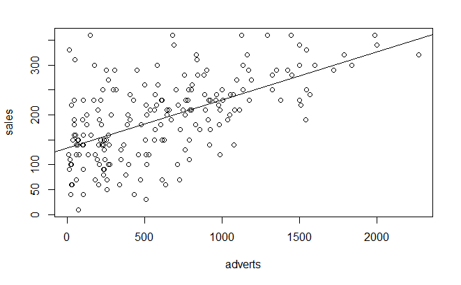

```r
album1<- read.delim("album.csv")
attach(album)
plot(adverts,sales)
abline(lm(sales~adverts))
```

```r
summary(albumSales.1)
```

```
Call:
lm(formula = album1$sales ~ album1$adverts)

Residuals:
     Min       1Q   Median       3Q      Max
-152.949  -43.796   -0.393   37.040  211.866

Coefficients:
                Estimate Std. Error t value Pr(>|t|)
(Intercept)    1.341e+02  7.537e+00  17.799   <2e-16 ***
album1$adverts 9.612e-02  9.632e-03   9.979   <2e-16 ***
---
Signif. codes:  0 *** 0.001 ** 0.01 * 0.05 . 0.1   1

Residual standard error: 65.99 on 198 degrees of freedom
Multiple R-squared:  0.3346,    Adjusted R-squared:  0.3313
F-statistic: 99.59 on 1 and 198 DF,  p-value: < 2.2e-16
```

## Multiple Regresion analysis

```r
attach(album2)
```

summary of second model

```r
summary(albumSales.2)
```

```
Call:
lm(formula = sales ~ adverts, data = album2)

Residuals:
     Min       1Q   Median       3Q      Max
-152.949  -43.796   -0.393   37.040  211.866

Coefficients:
             Estimate Std. Error t value Pr(>|t|)
(Intercept) 1.341e+02  7.537e+00  17.799   <2e-16 ***
adverts     9.612e-02  9.632e-03   9.979   <2e-16 ***
---
Signif. codes:  0 *** 0.001 ** 0.01 * 0.05 . 0.1   1

Residual standard error: 65.99 on 198 degrees of freedom
Multiple R-squared:  0.3346,    Adjusted R-squared:  0.3313
F-statistic: 99.59 on 1 and 198 DF,  p-value: < 2.2e-16
```

```r
summary(albumSales.3)
```

```
Call:
lm(formula = sales ~ adverts + airplay + attract, data = album2)

Residuals:
     Min       1Q   Median       3Q      Max
-121.324  -28.336   -0.451   28.967  144.132

Coefficients:
              Estimate Std. Error t value Pr(>|t|)
(Intercept) -26.612958  17.350001  -1.534    0.127
adverts       0.084885   0.006923  12.261  < 2e-16 ***
airplay       3.367425   0.277771  12.123  < 2e-16 ***
attract      11.086335   2.437849   4.548 9.49e-06 ***
---
Signif. codes:  0 *** 0.001 ** 0.01 * 0.05 . 0.1   1

Residual standard error: 47.09 on 196 degrees of freedom
Multiple R-squared:  0.6647,    Adjusted R-squared:  0.6595
F-statistic: 129.5 on 3 and 196 DF,  p-value: < 2.2e-16
```

obtener los coeficientes b estandarizados de manera que no depende de las unidades en las cuales hayan sido introducidos los datos. Estos coeficientes estandarízados están reportados en unidades de desviación estandar y reportan el cambio en desviaciones standard asociados a cada uno de los predictores. De esta forma los resultados son comparables y puede establecerce que tan importantes son en el modelo.

```r
lm.beta(albumSales.3)
```

```
  adverts   airplay   attract
0.5108462 0.5119881 0.1916834
```

intervalos de confianza

```r
confint(albumSales.3)
```

```
                   2.5 %      97.5 %
(Intercept) -60.82960967  7.60369295
adverts       0.07123166  0.09853799
airplay       2.81962186  3.91522848
attract       6.27855218 15.89411823
```

Podemos comparar los diferentes modelos usando la fucion anova(). dado que hemos creado dos modelos de regresión jerarquicos podemos hacer la comparación de estos modelos

```r
anova(albumSales.2, albumSales.3)
```

```
Analysis of Variance Table

Model 1: sales ~ adverts
Model 2: sales ~ adverts + airplay + attract
  Res.Df    RSS Df Sum of Sq      F    Pr(>F)
1    198 862264
2    196 434575  2    427690 96.447 < 2.2e-16 ***
---
Signif. codes:  0 *** 0.001 ** 0.01 * 0.05 . 0.1   1
```

algunos derivados del modelo lineal general pueden ser obtenidos con diversas funciones.las podndremos todas en el mismo dataframe

```r
album2$residuals<-resid(albumSales.3)
album2$standardized.residuals<- rstandard(albumSales.3)
album2$studentized.residuals<-rstudent(albumSales.3)
album2$cooks.distance<-cooks.distance(albumSales.3)
album2$dfbeta<-dfbeta(albumSales.3)
album2$dffit<-dffits(albumSales.3)
album2$leverage<-hatvalues(albumSales.3)
album2$covariance.ratios<-covratio(albumSales.3)
```

evaluar los supuestos de independencia de los datos

```r
durbinWatsonTest(albumSales.3)
```

```
 lag Autocorrelation D-W Statistic p-value
   1       0.0026951      1.949819   0.786
 Alternative hypothesis: rho != 0
```

para evaluar el supuesto de nolinearidad entre las variables predictoras puede usarse la función vif(). solo necesita invocarse

```r
car::vif(albumSales.3)
```

```
 adverts  airplay  attract
1.014593 1.042504 1.038455
```

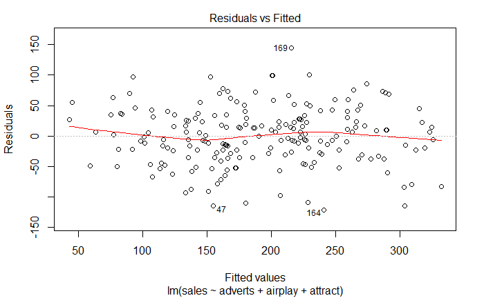

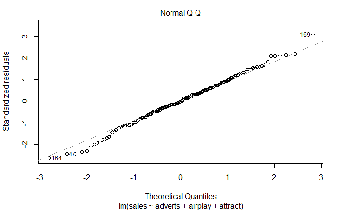

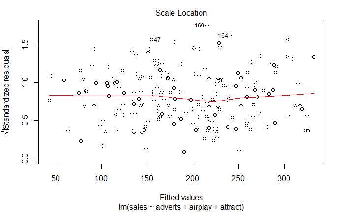

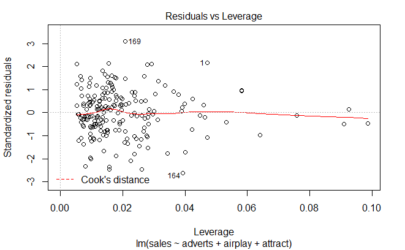

```r
bootResults<-boot(statistic = bootReg, formula = sales ~ adverts + airplay +
attract, data = album2, R = 2000)
```

```
Error in `[.data.frame`(data, i, ) : object 'i' not found
```

```r
levels(gfr$MUSIC)
```

```
[1] "1" "2" "3" "4"
```

```r
contrasts(gfr$music)<-contr.treatment(4, base = )
```

```
Unknown or uninitialised column: 'music'.Error in `contrasts<-`(`*tmp*`, value = c(0, 1, 0, 0, 0, 0, 1, 0, 0, 0,  :
  contrasts apply only to factors
```